# Airline Delay Prediction Report for American Airlines

Correlation test + plot

```r
 library(tidyverse)
library(here)
library(readr)
library(future.apply)
library(dplyr)
library(httr)
library(jsonlite)
library(RColorBrewer)
library(scales)
library(feather)
library(caret)
library(corrplot)
library(PerformanceAnalytics)
library(Hmisc)
# ========================
# Correlation test
mlm_corr <- read_feather(here('Dataset', 'USE MLM 5 mlm_dataset_3.feather' ))
# get a random sample of 50,000 observations
 mlm_corr_n <- mlm_corr %>% sample_n(50000)
mlm_corr_n <- mlm_corr_n %>% select(dep_delay,month,day_of_week, dep_time, arr_delay, air_time, air_time,taxi_out,taxi_in,age)
corr_matrix <- cor(mlm_corr_n, method = "pearson", use = "complete.obs")
corr_matrix <-round(corr_matrix,3)
corr_matrix
corrplot(corr_matrix, method = "ellipse")
corrplot(corr_matrix, method = "pie")
corr_matrix_r <- rcorr(corr_matrix, type = c("pearson","spearman"))
corrplot(corr_matrix_r$r, type = "upper", order = "hclust",
p.mat = corr_matrix_r$P, sig.level = 0.01, insig = "blank")
chart.Correlation(corr_matrix, histogram = TRUE, pch = 19)
# =========================
```

Clean data

```r
# Removing unused columns

clean_months <- clean_months %>%
  select('year', 'quarter', 'month', 'day_of_month', 'day_of_week',
         'fl_date', 'tail_num', 'op_carrier_fl_num', 'origin_state_abr',
         'dest_state_abr', 'dep_time', 'dep_delay',
         'dep_delay_new', 'taxi_out', 'taxi_in', 'arr_time', 'arr_delay',
         'arr_delay_new', 'air_time', 'distance', 'carrier_delay',
         'weather_delay', 'nas_delay', 'security_delay',
         'late_aircraft_delay', 'first_dep_time', 'total_add_gtime',
         'airline', 'origin_airportname', 'origin_airport_code',
         'dest_airportname','dest_airport_code')

# Change column types

wrong_columns <- c('quarter', 'month', 'day_of_month', 'day_of_week',
                   'op_carrier_fl_num', 'dep_time', 'arr_time', 'first_dep_time')

clean_months[wrong_columns] <- future_lapply(clean_months[wrong_columns], factor)


# Check columns

col_status_cleaner <- status(clean_months)

#write interim feather file

write_feather(clean_months, here('clean_allairlines.feather'))

# Select only AA, DL, and UA
target = ('American Airlines inc.')

test <- clean_months %>%
  filter(airline %in% c('American Airlines Inc.',
                        'Delta Air Lines Inc.',
                        'United Air Lines Inc.'))

unique(test$airline)

# Save new dataset

write_feather(test, here('clean_3airlines.feather'))

wrong_columns <- c('age', 'model_year')

clean_months['age'] <- future_lapply(clean_months['age'], as.numeric)
clean_months['model_year'] <- future_lapply(clean_months['model_year'], as.factor)


# Check columns

col_status_cleaner <- status(clean_months)

#write interim feather file

write_feather(clean_months, here('clean_3airline_fleet_employ_2.feather'))
```

Chi-square independence test + point-biseral test

```r
#chi-square independence test, dep_delay against other variables
library(broom)
CHIS <- lapply(allmonths[,-1], function(x) chisq.test(allmonths[,1], x))
chi_result <- do.call(rbind, lapply(CHIS,tidy))

dmy <- dummyVars(" ~ . ", data= clean_months, fullRank = T)
dat_transformed <- data.frame(predict(dmy, newdata = clean_months))

#correlation test (including everything)
corr_result_all <- round(cor(dat_transformed), digits = 2)

sink('corr_result_all.txt')
corr_result_all
sink()
```

Linear regression code

```r
library(tidyverse)
library(here)
library(readr)
library(future.apply)
library(dplyr)
library(httr)
library(jsonlite)
library(RColorBrewer)
library(scales)
library(feather)
library(caret)
library(corrplot)
library(Boruta)


mlm_final <- read_feather(here('mlm_dataset_5.feather'))

# sqrt transoformation
#mlm_final$dep_delay <- sqrt(mlm_final$dep_delay)


# Select California only as Subset

mlm_CA <- mlm_final %>% filter(origin_state_abr == 'CA')
names(mlm_CA)

mlm_all <- mlm_CA %>%
  select(-origin_state_abr) %>%
  droplevels()

str((mlm_all))

View(mlm)


# Numerical data transformation
data <- mlm_all #change this to your data name
trimming <- FALSE #change this to true if you want to trim data



min_max_norm <- function(x){
  (x-min(x)) / (max(x) - min(x))
}

num_col <- select_if(mlm_all, is.numeric)

num_col_norm <- as.data.frame(lapply(num_col, min_max_norm))
cat_col <- mlm_all %>% select_if(negate(is.numeric))
num_col_norm$id <- seq.int(nrow(mlm_all))
cat_col$id <- seq.int(nrow(mlm_all))
combine_data <- left_join(num_col_norm, cat_col, by = 'id')
mlm_all <- combine_data %>% select(-id)

names(mlm_CA)
names(mlm_all)

# MLM on Most logical variables

mlm1 <- lm(dep_delay ~ month + day_of_week + dest_state_abr + dep_time +
             airline + taxi_out + origin_airport_code + dest_airport_code +
             air_time + taxi_in + manufacturer + model + age +
             emptotal, data = mlm_all)
summary(mlm1) # R-Squared 0.03944 p < 2.2e-16
plot(mlm1)

# MLM removal

mlm2 <- lm(dep_delay ~ month + day_of_week + dep_time +
             airline + taxi_out + origin_airport_code + dest_airport_code +
             air_time + model + age, data = mlm_all)
summary(mlm2) # R Squared 0.03184
plot(mlm2)


# MLM removal 2

mlm3 <- lm(dep_delay ~ month + day_of_week + dep_time +
             airline + taxi_out + origin_airport_code +
            model + age, data = mlm_all)
summary(mlm3) # R-Squared 0.02715

# Run Boruta
boruta_sasuke <- Boruta(dep_delay ~ month + day_of_week + dep_time +
                        airline + taxi_out + origin_airport_code +
                        model + age, data = mlm_all, doTrace = 2)

boruta_signif <- names(boruta_sasuke$finalDecision[boruta_sasuke$finalDecision %in% c("Confirmed", "Tentative")])
print(boruta_signif)
plot(boruta_sasuke, cex.axis = .7,
     las = 2, xlab ="", main = "Variable Importance")


# MLM boruta removal

mlm4 <- lm(dep_delay ~ month + dep_time +
             airline + taxi_out + origin_airport_code +
             model + age, data = mlm_all)
summary(mlm4) # R-Squared  .02705


mlm5 <- lm(dep_delay ~ month + dep_time +
             airline + age, data = mlm_all)
summary(mlm5) # R-Squared .01202 p-value <2.2e-16



mlm6 <- lm(arr_delay ~ month + day_of_week + dep_time +
             airline + taxi_out + dest_airport_code +
             air_time + taxi_in + manufacturer + age,
             data = mlm_all)

summary(mlm6)

#improve upon mlm6 but added interaction varaible
mlm_7 <- lm(dep_delay ~ month + dep_time +
              airline + age + month:age +
              airline:age + airline:dep_time
            , data = mlm_all)

summary(mlm_7)
#interaction variable not significant --> no need to add interaction variable

#sqrt transformation
mlm_final$dep_delay <- sqrt(mlm_final$dep_delay)

#VIF
VIF(mlm5)
A1/VIF(mlm5)

summary_test

summary_txt <- summary(mlm1)

sink('second_summary.txt')
summary_txt
sink()

# Model diagnoistic

pairs(mlm_CA)
corrplot(cor(mlm_CA_sub3), method = "number")



# Residual Plot on MLM 5

plot(mlm5)
```

```r
library(tidyverse)
library(here)
library(readr)
library(future.apply)
library(dplyr)
library(httr)
library(jsonlite)
library(RColorBrewer)
library(scales)
library(feather)
library(caret)
library(corrplot)
library(Boruta)
library(regclass)


# 1. Load Data -----
mlm_final <- read_feather(here('mlm_dataset_5.feather'))

summary(mlm_final)
#dep delay median is -3
#select delays greater than 0

blm_bino <- mlm_final %>%
  filter(dep_delay > 0)

summary(blm_bino)
#dep delay median is 12, mean 20.8. 1Q 4, 3Q 30


# 2. Create new binomial delay

blm_bino <- blm_bino %>%
  mutate(delay_new = dep_delay > 12)

summary(blm_bino)
#344677 true, #356513 false


# 3. Train/Test set data

blm_bino$id <- 1:nrow(blm_bino)
blm_bino.train <- blm_bino %>% dplyr::sample_frac(0.75)
blm_bino.test <- dplyr::anti_join(blm_bino, blm_bino.train, by ='id')


# 3. GLM model
glm0 <- glm(delay_new ~ month + day_of_week + dest_state_abr + dep_time +
              airline + taxi_out + origin_airport_code + dest_airport_code +
              air_time + taxi_in + manufacturer + model + age +
              emptotal, family = binomial(logit), data = mlm_bino.train)
summary(glm0)

glm1 <- glm(delay_new ~ month + dep_time +
              airline + taxi_out +
              model + age, family = binomial(logit), data = mlm_bino.train)
summary(glm1)


# 4. Model only for AA

blm_aa.train <- blm_bino.train %>%
  filter(airline == 'American Airlines Inc.')

blm_aa.test <- blm_bino.test %>%
  filter(airline == 'American Airlines Inc.')

# 5. GLM model for AA

blm2 <- glm(delay_new ~ month + dep_time +
              model,
              family = binomial(logit), data = blm_aa.train)
summary(blm2)


# 6. Model only for DL

blm_dl.train <- blm_bino.train %>%
  filter(airline == 'Delta Air Lines Inc.')

blm_dl.test <- blm_bino.test %>%
  filter(airline == 'Delta Air Line Inc.')

blm_ua.train <- blm_bino.train %>%
  filter(airline == 'United Air Lines Inc.')

blm_ua.test <- blm_bino.test %>%
  filter(airline == 'United Air Line Inc.')


# 7. GLM model for DL

blm3 <- glm(delay_new ~ month + dep_time +
              + model,
            family = binomial(logit), data = blm_dl.train)
summary(blm3)

blm4 <- glm(delay_new ~ month + dep_time +
              model,
            family = binomial(logit), data = blm_ua.train)
summary(blm4)

# 8. Look at VIF for models
VIF(glm1)
VIF(blm2)
VIF(blm3)
VIF(blm4)

1/VIF(blm2)
# 9 model validation

probability_aa <- predict(blm2, newdata = blm_aa.test, type='response')
prediction_aa <- ifelse(probability_aa > 0.5, 1, 0)
confusion_aa <- table(blm_aa.test$delay_new, prediction_aa)

confusion_aa


# 10. Plots
library(DHARMa)

res <- simulateResiduals(blm2, plot = T)

# Table

library(knitr)
kable(confusion_aa, caption = "Confusion Matrix")
```

Clean data

Final Dataset: After joining all our datasets into one, we explored our data in detail: Airlines were reduced to include only American Airlines and two main competitors (Delta and United Airlines), reducing observations from 12M to approximately 4M. Observations missing the type of aircraft were removed, taking our observations down to 2.8M. Column names were cleaned under the same format. Variable selection, only variables that could represent a potential impact for airline delays were taken into consideration. Redundant (ie: 5 different fields indicating state: State, State ID, State FIPS and State NM) and non important variables were removed, taking our total number of fields from 65 to 32 and finally to just 19. Cleaning categorical variables that were incorrectly set as numerical. In order to reduce the size of our data set and make it easier for all of us to handle it we used [data.table] and [feather] packages, taking it down from 7GB to 1.5 GB. After doing this we continued with our variable inspections and removed the taxi-in and airtime variables with values below 0, which would indicate the flight did not happen. Cleaning the Manufacturer observations, for example, grouping all the BOEING Values into one, BOEING, Boeing Charleston, Boeing SC, etc were transformed into just “Boeing”. Cleaning the aircraft type variations by grouping all the similar types together, for example all the 737 similar variants such as 737 classic, next generation, 700, 800 and 900 were all classified as “737”. Cleaning the Dep_Time variable by transforming it to a time variable (HH:MM) 24 hour time format using [hms], [as.POSIXct].

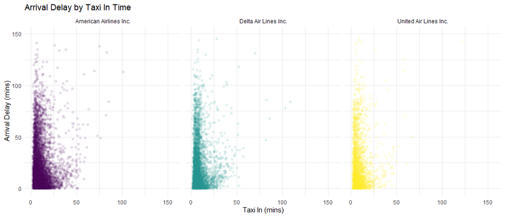

When analyzing arrival delays and taxi in time we did not find a clear relation between these two variables, something interesting that we found here is that taxi in time is usually pretty low and therefore wont represent that big of an impact in the overall performance. It is important to note that American Airlines seems to not only have a higher average taxi-in time but also a bigger number of outliers in this regard.

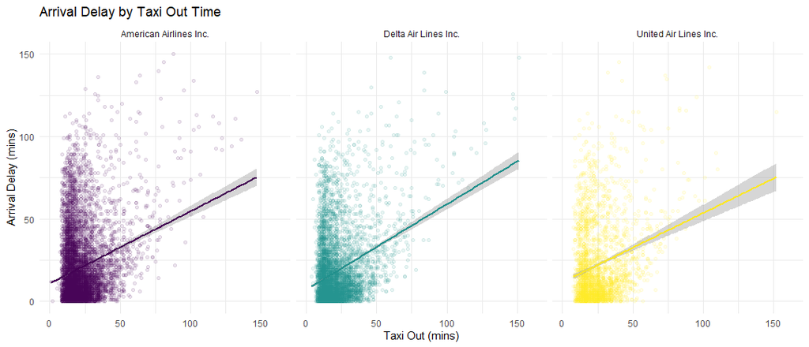

Looking at taxi out time we found a higher relationship with arrival delays than with taxi-in. We also noticed that the taxi out times are considerably higher and therefore represent a bigger impact on the overall on-time performance.

### Summary Statistics

```r
library(funModeling)
library(Hmisc)
library(DataExplorer)

summary(delay)
status(delay)
```

[output not shown]

#### 4.2.1.1 Interpretation

Year: The number of observations in the year 2019 1.76 million, while it decreases remarkably in 2020 to 920.2 thousand. This clearly shows the impact COVID-19 had on the Airline industry. We have only first quarter data for 2021, so the observations there are insignificant in this context. Month: The six months of Jan, Feb, Mar, Jul, Aug and Oct have more flights than the remaining months of the year. Day of the week: The number of flights each day were almost the same. It did not vary significantly based on weekdays or weekend demands.

Origin State and Destination State: Most of the flight originates or arrives from these six states (in descending order). Texas - TX Georgia - GA Florida - FL California - CA North Carolina - NC Illinois - IL

Air time: This shows closer to a standard distribution with a right skewness.

Airline: American Airline and Delta Airline have the largest share of the three major players (43% and 39% respectively). United Airlines has a 17% share.

Taxi Out and Taxi In: They have closer values of Median and Mean as compared to other variables. Both are right skewed due to a large value of outliers which influence the mean.